# Actuarial 3 Tarea 1

Actuarial 3

Autor/a

Marcelino Sánchez

Fecha de publicación

26 de septiembre de 2023

# Ejercicio 1

Suponga que $Y_i$ es el número de reclamaciones anuales de cierta póliza de seguros y que su distribución es Po $\left(\lambda\right)$ , donde $\lambda$ es desconocido, pero su distribución a priori es $Gamma\left(\alpha,\theta\right)$. Si el número de reclamaciones de los últimos $n$ años, $Y_1, Y_2,..., Y_n$, son variables aleatorias iid, y $W$ es el número de reclamaciones de este año, aplique la Metodología Bayesiana para responder lo siguiente:

1. Calcule la distribución posterior del parámetro $\lambda$ . [10]
2. Obtenga la distribución marginal de los datos. [10]
3. ¿Cuál es la distribución predictiva de $W$? [10]
4. Encuentre esperanza y varianza de $W$. ¿Cómo se puede interpretar la media condicional? (Sugerencia: Utilice esperanza y varianza iteradas). [10]

**Ejercicio e)**

Si en los últimos 5 años se tuvieron 120 siniestros, y con información de mercado se sabe que $\alpha = 4$ y $\theta = 5$, calcule:

1. El estimador puntual de $\lambda$ considerando la función de pérdida cero-uno. [5]

Como la función de pérdida es cero-uno, entonces por teoremas bayesianos y siguiendo el mismo flujo de inferencia tenemos que el estimador puntual a posteriori de $\lambda$ es la moda de la distribución posterior.

Como la distribución posterior es una $Gamma((\sum_{i=1}^{5}y_{i})+\alpha, \frac{\theta}{n\theta + 1})$ entonces la moda es:

$$\hat{\lambda}= ((\sum_{i=1}^{5}y_{i})+\alpha-1)(\frac{\theta}{n\theta + 1})$$

```r
ndatos<- 5
conteo_siniestros <- 120
alpha<- 4
theta <- 5

lambdahat <- (conteo_siniestros + alpha - 1)*(theta/(ndatos*theta + 1))
```

Por lo que tomando en cuenta los datos de los últimos años $\sum_{i=1}^{5}y_{i}=120$, tenemos que el estimador a posteriori tiene el valor de $\hat{\lambda}= 23.6538462$

2. El intervalo de máxima densidad posterior al 95% para $\lambda$. [5]

```r
# Definimos la función que queremos minimizar
alpha <- conteo_siniestros + 4 - 1
theta <- 5/(ndatos*5 + 1)

funcion_objetivo <- function(x) {
  return(qgamma(pgamma(x, shape=alpha,
  scale = theta)+.95, shape=alpha,
  scale = theta)-x)
}

# Utilizamos la función optim() para encontrar el mínimo
resultado <- optim(par=lambdahat,
fn=funcion_objetivo, method="L-BFGS-B",
lower = 0, upper = qgamma(.05, shape=alpha,
 scale = theta)-.0001)
```

El intervalo de máxima densidad posterior al 95% para lambda es [19.5383685 , 27.8777022] # Ejercicio 3

# Función Gamma Incompleta

Si $\Gamma(\alpha; x) = \int_{0}^{x} y^{\alpha-1} e^{-y} dy$ para $\alpha > 0$ y $x > 0$

1. Demuestre que

$\Gamma(\alpha; x) = \Gamma(\alpha) \left( 1 - \sum_{j=0}^{\alpha-1} \frac{x^j e^{-x}}{j!} \right)$

si $\alpha \in \mathbb{Z}^+$. (Sugerencia: Demuestre por inducción matemática sobre $\alpha$). [5]

2. El Complemento de la Función Gamma Incompleta se define por

$G(\alpha; x) = \int_{x}^{\infty} y^{\alpha-1} e^{-y} dy.$ Demuestre que

$G(\alpha+k; x) = \Gamma(\alpha+k) \left( 1 - \frac{\Gamma(\alpha+k; x) }{\Gamma(\alpha+k)}\right)$ [10]

3. A partir de una muestra aleatoria de 10 reclamaciones de una distribución Gamma se observaron las siguientes pérdidas (en dólares): 1,500, 6,000, 3,500, 3,800, 1,800, 5,500, 4,800, 4,200, 3,900, 3,000. Si se sabe que $\alpha = 12$, encuentre el EMV de la probabilidad de que una pérdida supere 6,000 pesos. [5]

```r
sumaReclamaciones <- 1500 + 6000 + 3500 + 3800 + 1800 + 5500 + 4800 + 4200 + 3900 + 3000

alpha <- 12

n=10

beta_gorro <- sumaReclamaciones/(n*alpha)

lower_incomplete_gamma <- function(a, x) {
  gamma(a) * pgamma(x, shape = a, rate = 1, lower.tail = TRUE)
}

estimador <- 1 - lower_incomplete_gamma(alpha, 6000/beta_gorro)/gamma(alpha)
```

Con lo cual tenemos que la probabilidad estimada (por EMV) de que una pérdida supere los 6000 pesos es de 0.0355428

# Ejercicio 6

# Mezclas

Suponga que $X_i \sim \text{Exp}(\lambda_i)$, $\lambda_i > 0$, $i = 1, 2, \dots$

1. Considere una mezcla finita de $K$ componentes variables. Obtenga su respectiva función de distribución acumulada, su función de densidad y su tasa de riesgo. ¿Cuántos parámetros habría en el modelo si $K = 4$? [10]
2. El 75% de las reclamaciones tienen una distribución Exponencial con media de 3 mil dólares y el restante 25% una distribución Exponencial con media de 5 mil dólares. Obtenga la gráfica de la función de densidad de esta mezcla y calcule la probabilidad de que una reclamación exceda los 6 mil dólares. [10]

Tenemos que la función de densidad que describe las reclamaciones es:

$$f(x;\theta)=(.75\lambda_{1}e^{-\lambda_{1}x}+.25\lambda_{2}e^{-\lambda_{2}x})\mathbb{I}_{(0,\infty)}(x)$$

Donde $\lambda_{1}=\frac{1}{3}$ y $\lambda_{2}=\frac{1}{5}$ tomando en cuenta que escalamos los datos para que resultasen en miles de dólares.

La gráfica para esta distribución mezcla es la siguiente:

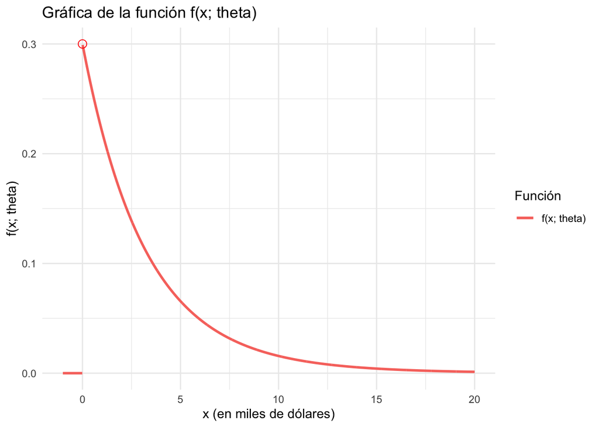

```r
library(ggplot2)

lambda1 <- 1/3
lambda2 <- 1/5

# Define the function f(x; theta)
densidadMezcla <- function(x, lambda1 = 1/3, lambda2 = 1/5) {
  0.75 * dexp(x, rate = lambda1) + 0.25 * dexp(x, rate = lambda2)
}

probabilidadMezcla <- function(x, lambda1 = 1/3, lambda2 = 1/5) {
  0.75 * pexp(x, rate = lambda1) + 0.25 * pexp(x, rate = lambda2)
}

# Create a dataset to plot using geom_line
data_points <- data.frame(x = seq(-1, 20, by = 0.01))
data_points$y <- densidadMezcla(data_points$x)

# Split the data at x=0
data_left <- subset(data_points, x < 0)
data_right <- subset(data_points, x > 0)

# Plot the function in the interval [-1, 20]
ggplot() +
  geom_line(data = data_left, aes(x = x, y = y, colour = "f(x; theta)"), size = 1) +
  geom_line(data = data_right, aes(x = x, y = y, colour = "f(x; theta)"), size = 1) +
  geom_point(aes(x = 0, y = densidadMezcla(0)), color = "red", size = 3, shape = 1) +
  labs(title = "Gráfica de la función f(x; theta)",
       x = "x (en miles de dólares)",
       y = "f(x; theta)",
       colour = "Función") +
  theme_minimal()
```

Y por último, la probabilidad de que una reclamación exceda los 6000 dólares es de 0.17680002

3. Suponga que $X \sim \text{Exp}(\Lambda)$ y que $\Lambda \sim \text{Gamma}(\alpha,\beta)$ para construir una mezcla continua. Obtenga la densidad marginal de $X$, su esperanza y su varianza. [10]